# DDS Case Study 2 - Firto Lay

Edgar Nunez

12/5/2019

The folowing is an analysis of the Case Study 2 data set for Frito Lay’s Employee Attrition. The objectives of this analysis are to identify factors that lead to attrition and to build a model to predict attrition.

## R Markdown

##Data exploration and preparation analysis

```
##        ID             Age        Attrition           BusinessTravel
##  Min.   :  1.0   Min.   :18.00   No :730   Non-Travel       : 94
##  1st Qu.:218.2   1st Qu.:30.00   Yes:140   Travel_Frequently:158
##  Median :435.5   Median :35.00             Travel_Rarely    :618
##  Mean   :435.5   Mean   :36.83
##  3rd Qu.:652.8   3rd Qu.:43.00
##  Max.   :870.0   Max.   :60.00
##
##    DailyRate                       Department  DistanceFromHome
##  Min.   : 103.0   Human Resources       : 35   Min.   : 1.000
##  1st Qu.: 472.5   Research & Development:562   1st Qu.: 2.000
##  Median : 817.5   Sales                 :273   Median : 7.000
##  Mean   : 815.2                                Mean   : 9.339
##  3rd Qu.:1165.8                                3rd Qu.:14.000
##  Max.   :1499.0                                Max.   :29.000
##
##    Education              EducationField EmployeeCount EmployeeNumber
##  Min.   :1.000   Human Resources : 15    Min.   :1     Min.   :   1.0
##  1st Qu.:2.000   Life Sciences   :358    1st Qu.:1     1st Qu.: 477.2
##  Median :3.000   Marketing       :100    Median :1     Median :1039.0
##  Mean   :2.901   Medical         :270    Mean   :1     Mean   :1029.8
##  3rd Qu.:4.000   Other           : 52    3rd Qu.:1     3rd Qu.:1561.5
##  Max.   :5.000   Technical Degree: 75    Max.   :1     Max.   :2064.0
##
##  EnvironmentSatisfaction    Gender      HourlyRate     JobInvolvement
##  Min.   :1.000           Female:354   Min.   : 30.00   Min.   :1.000
##  1st Qu.:2.000           Male  :516   1st Qu.: 48.00   1st Qu.:2.000
##  Median :3.000                        Median : 66.00   Median :3.000
##  Mean   :2.701                        Mean   : 65.61   Mean   :2.723
##  3rd Qu.:4.000                        3rd Qu.: 83.00   3rd Qu.:3.000
##  Max.   :4.000                        Max.   :100.00   Max.   :4.000
##
##     JobLevel                          JobRole    JobSatisfaction
##  Min.   :1.000   Sales Executive          :200   Min.   :1.000
##  1st Qu.:1.000   Research Scientist       :172   1st Qu.:2.000
##  Median :2.000   Laboratory Technician    :153   Median :3.000
##  Mean   :2.039   Manufacturing Director   : 87   Mean   :2.709
##  3rd Qu.:3.000   Healthcare Representative: 76   3rd Qu.:4.000
##  Max.   :5.000   Sales Representative     : 53   Max.   :4.000
##                  (Other)                  :129
```

[output cut: 25 more lines]

```
##  Min.   :1.000   Min.   : 0.000   Min.   : 0.000
##  1st Qu.:2.000   1st Qu.: 3.000   1st Qu.: 2.000
##  Median :3.000   Median : 5.000   Median : 3.000
##  Mean   :2.782   Mean   : 6.962   Mean   : 4.205
##  3rd Qu.:3.000   3rd Qu.:10.000   3rd Qu.: 7.000
##  Max.   :4.000   Max.   :40.000   Max.   :18.000
##
##  YearsSinceLastPromotion YearsWithCurrManager
##  Min.   : 0.000          Min.   : 0.00
##  1st Qu.: 0.000          1st Qu.: 2.00
##  Median : 1.000          Median : 3.00
##  Mean   : 2.169          Mean   : 4.14
##  3rd Qu.: 3.000          3rd Qu.: 7.00
##  Max.   :15.000          Max.   :17.00
##
```

#Data Structure

```
## 'data.frame':    870 obs. of  36 variables:
##  $ ID                      : int  1 2 3 4 5 6 7 8 9 10 ...
##  $ Age                     : int  32 40 35 32 24 27 41 37 34 34 ...
##  $ Attrition               : Factor w/ 2 levels "No","Yes": 1 1 1 1 1 1 1 1 1 1 ...
##  $ BusinessTravel          : Factor w/ 3 levels "Non-Travel","Travel_Frequently",..: 3 3 2 3 2 2 3 3 3 2 ...
##  $ DailyRate               : int  117 1308 200 801 567 294 1283 309 1333 653 ...
##  $ Department              : Factor w/ 3 levels "Human Resources",..: 3 2 2 3 2 2 2 3 3 2 ...
##  $ DistanceFromHome        : int  13 14 18 1 2 10 5 10 10 10 ...
##  $ Education               : int  4 3 2 4 1 2 5 4 4 4 ...
##  $ EducationField          : Factor w/ 6 levels "Human Resources",..: 2 4 2 3 6 2 4 2 2 6 ...
##  $ EmployeeCount           : int  1 1 1 1 1 1 1 1 1 1 ...
##  $ EmployeeNumber          : int  859 1128 1412 2016 1646 733 1448 1105 1055 1597 ...
##  $ EnvironmentSatisfaction : int  2 3 3 3 1 4 2 4 3 4 ...
##  $ Gender                  : Factor w/ 2 levels "Female","Male": 2 2 2 1 1 2 2 1 1 2 ...
##  $ HourlyRate              : int  73 44 60 48 32 32 90 88 87 92 ...
```

[output cut: 22 more lines]

#Data Dimension

```
## [1] 870  36
```

## UNivariate and Bi-variate analysis

## Correlation Plot

```
## 'data.frame':    870 obs. of  25 variables:
##  $ Age                     : int  32 40 35 32 24 27 41 37 34 34 ...
##  $ DailyRate               : int  117 1308 200 801 567 294 1283 309 1333 653 ...
##  $ DistanceFromHome        : int  13 14 18 1 2 10 5 10 10 10 ...
##  $ Education               : int  4 3 2 4 1 2 5 4 4 4 ...
##  $ EmployeeNumber          : int  859 1128 1412 2016 1646 733 1448 1105 1055 1597 ...
##  $ EnvironmentSatisfaction : int  2 3 3 3 1 4 2 4 3 4 ...
##  $ HourlyRate              : int  73 44 60 48 32 32 90 88 87 92 ...
##  $ JobInvolvement          : int  3 2 3 3 3 3 4 2 3 2 ...
##  $ JobLevel                : int  2 5 3 3 1 3 1 2 1 2 ...
##  $ JobSatisfaction         : int  4 3 4 4 4 1 3 4 3 3 ...
##  $ MonthlyIncome           : int  4403 19626 9362 10422 3760 8793 2127 6694 2220 5063 ...
##  $ MonthlyRate             : int  9250 17544 19944 24032 17218 4809 5561 24223 18410 15332 ...
##  $ NumCompaniesWorked      : int  2 1 2 1 1 1 2 2 1 1 ...
##  $ PercentSalaryHike       : int  11 14 11 19 13 21 12 14 19 14 ...
##  $ PerformanceRating       : int  3 3 3 3 3 4 3 3 3 3 ...
##  $ RelationshipSatisfaction: int  3 1 3 3 3 3 1 3 4 2 ...
##  $ StockOptionLevel        : int  1 0 0 2 0 2 0 3 1 1 ...
##  $ TotalWorkingYears       : int  8 21 10 14 6 9 7 8 1 8 ...
##  $ TrainingTimesLastYear   : int  3 2 2 3 2 4 5 5 2 3 ...
##  $ WorkLifeBalance         : int  2 4 3 3 3 2 2 3 3 2 ...
##  $ YearsAtCompany          : int  5 20 2 14 6 9 4 1 1 8 ...
##  $ YearsInCurrentRole      : int  2 7 2 10 3 7 2 0 1 2 ...
##  $ YearsSinceLastPromotion : int  0 4 2 5 1 1 0 0 0 7 ...
##  $ YearsWithCurrManager    : int  3 9 2 7 3 7 3 0 0 7 ...
##  $ numeric_Attrition       : num  0 0 0 0 0 0 0 0 0 0 ...
```

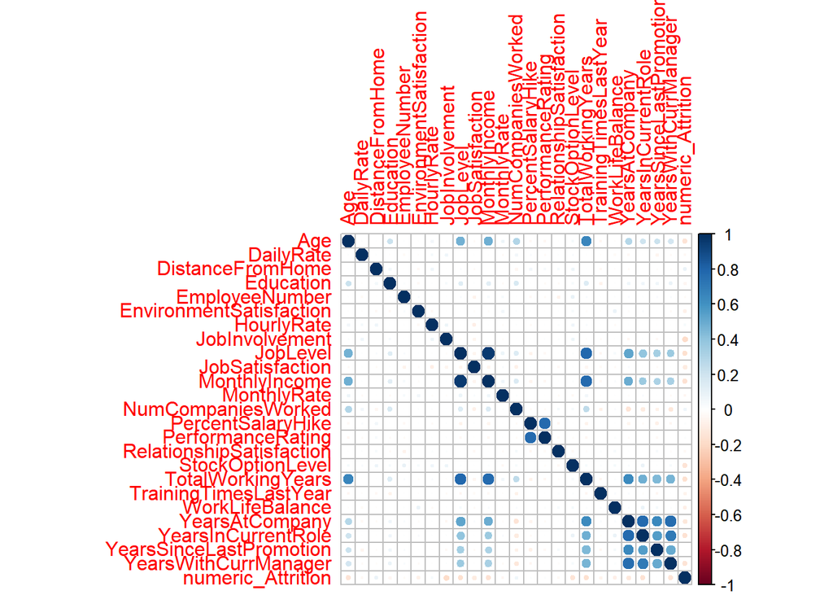

The correlation analysis reveled the following findings: the strongest correlation is between JobLevel and Monthly income, with correlation at 0.95 the more total working years, the more Job Level, with correlation at 0.780 the more total working years, the more Monthly Income, with correlation at 0.778 the more performance rating, the more Percent salary hike, with correlation at 0.775 the more yearsatcompany, the more yearsInCurrentRole, with correlation at 0.776 the more yearswithcurrmanager, the more yearsatcompany, with correlation at 0.765 the more yearswithcurrmanager, the more yearsincurrentrole, with correlation at 0.709

```
## [1] 9
## [1] ", "
## [1] 11
## [1] 0.95164
## [1] 9
## [1] ", "
## [1] 18
## [1] 0.7807524
## [1] 11
## [1] ", "
## [1] 9
## [1] 0.95164
## [1] 11
## [1] ", "
## [1] 18
```

[output cut: 41 more lines]

```
## [1] "how many:"
```

```
## [1] 7
```

## The Overtime vs Attiriton plot shows that, personnel who works more over time have more Attrition

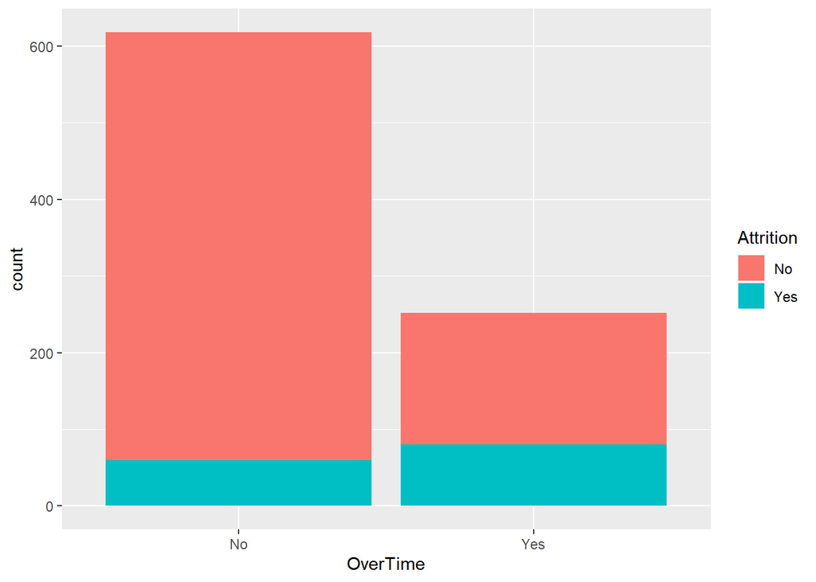

```
##         No        Yes
## 0.09708738 0.31746032
```

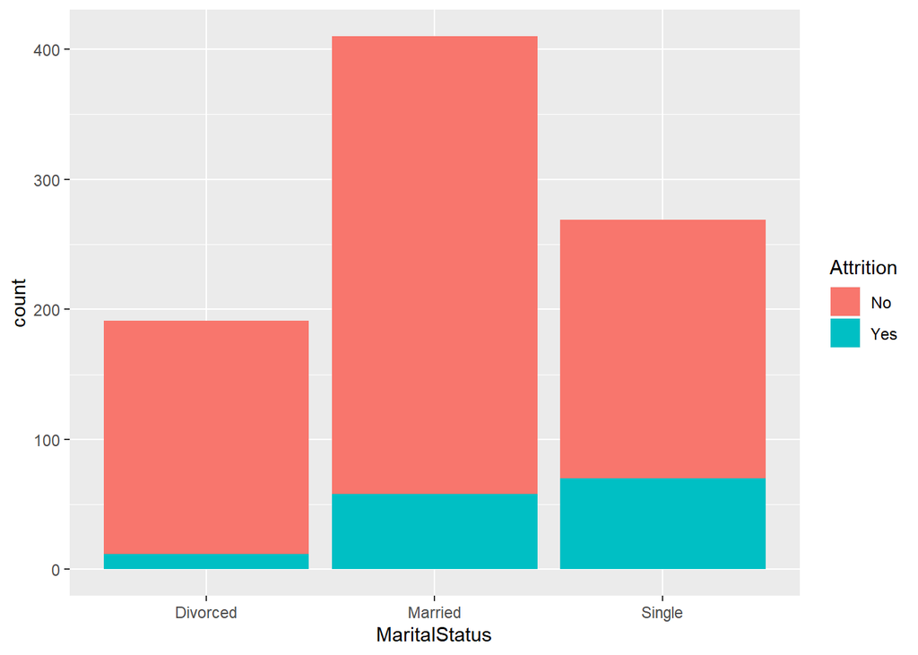

```
##   Divorced    Married     Single
## 0.06282723 0.14146341 0.26022305
```

## The JobRole vs Attrition plot shows that Laboratory Technician, Human Resources and Sales Representative roles have more attrition.

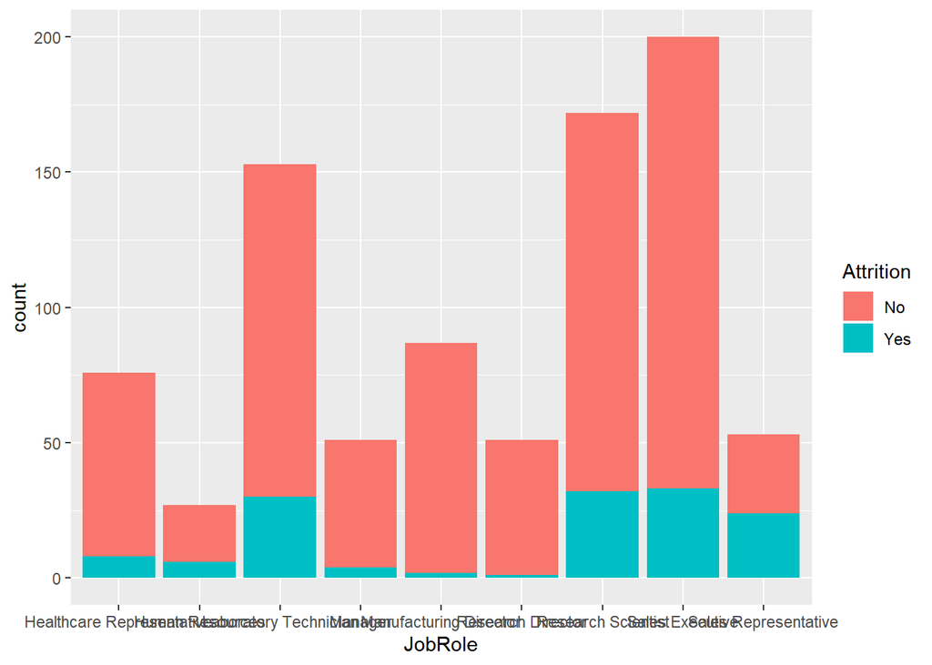

```
## Healthcare Representative           Human Resources
##                0.10526316                0.22222222
##     Laboratory Technician                   Manager
##                0.19607843                0.07843137
##    Manufacturing Director         Research Director
##                0.02298851                0.01960784
##        Research Scientist           Sales Executive
##                0.18604651                0.16500000
##      Sales Representative
##                0.45283019
```

```
## [1] 0.1609195
```

## The Gender vs Attrition plot shows that the gender characteristic is not significnt

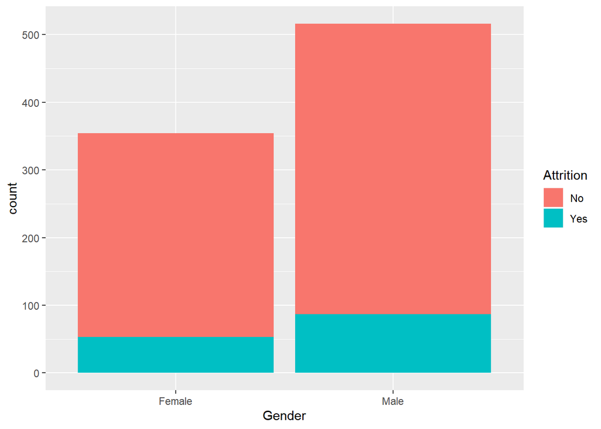

```
##    Female      Male
## 0.1497175 0.1686047
```

## The Education Field vs Attrition plot shows that Technical Degree and Human Resources have the highest attrition ratios.

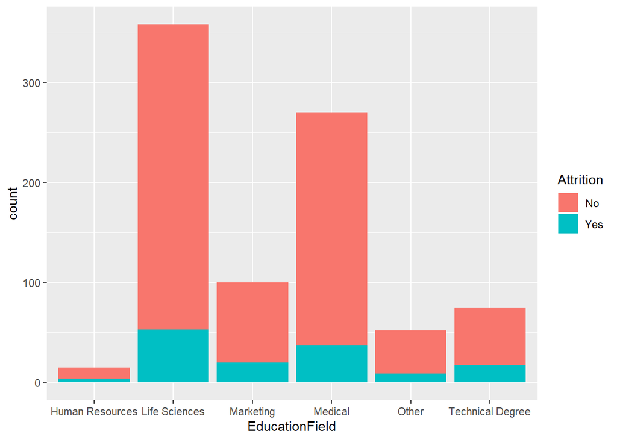

```
##  Human Resources    Life Sciences        Marketing          Medical
##        0.2666667        0.1480447        0.2000000        0.1370370
##            Other Technical Degree
##        0.1730769        0.2266667
```

## The Department vs Attrition plot show that the department attrition ratios are not significant

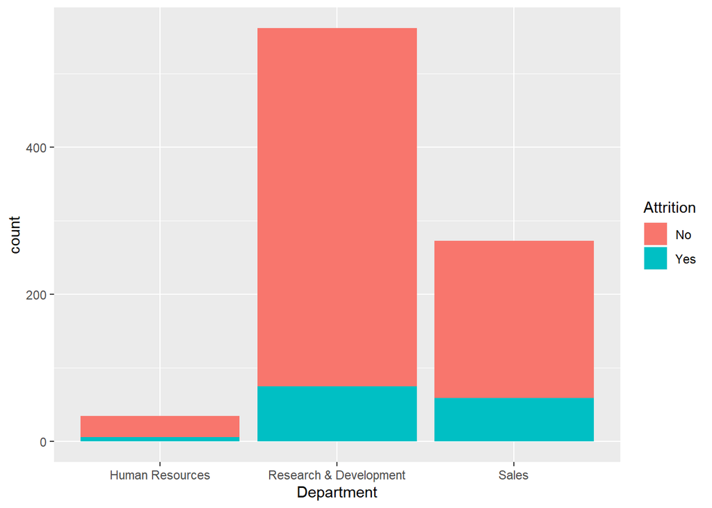

```
##        Human Resources Research & Development                  Sales
##              0.1714286              0.1334520              0.2161172
```

## The BusinessTravel vs Attrition plot shows that the ratio of attrition increases with increases in travel frequency increases.

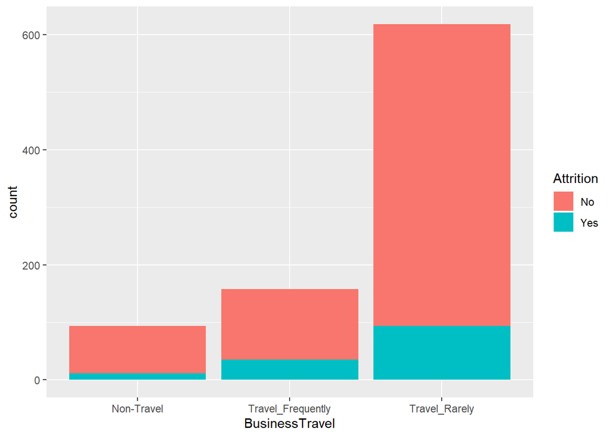

```
##        Non-Travel Travel_Frequently     Travel_Rarely
##         0.1170213         0.2215190         0.1521036
```

#Apparently, attrition ratio is cumulative when the following conditions are present: #OverTime = Yes, Marial_Status = Single & Age < 35

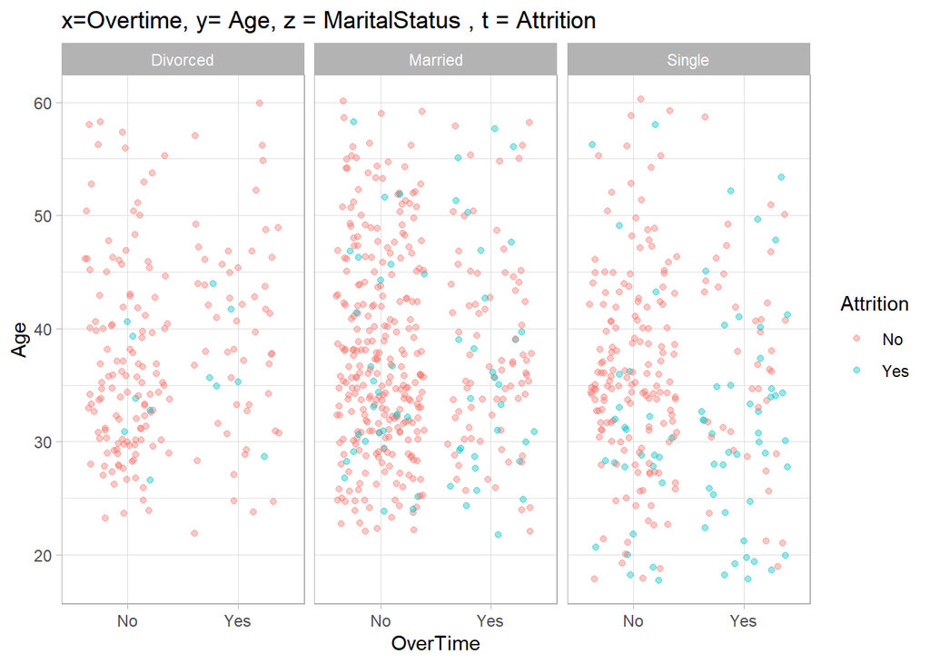

# The MonthlyIncome vs. Age plot shows that there is a tendency for MonthlyIncome to increase as Age increases. # Attrition frequency tends to decrease as monthly income increases

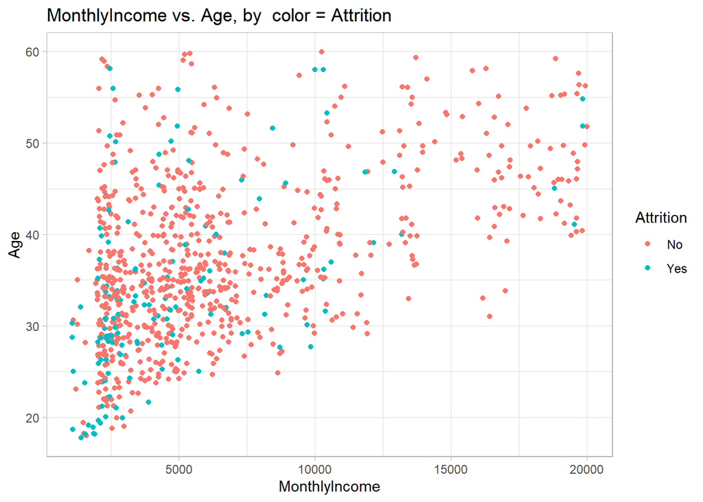

#Predicting attrition with KNN regression :

```
## 'data.frame':    870 obs. of  36 variables:
##  $ ID                      : int  1 2 3 4 5 6 7 8 9 10 ...
##  $ Age                     : int  32 40 35 32 24 27 41 37 34 34 ...
##  $ Attrition               : Factor w/ 2 levels "No","Yes": 1 1 1 1 1 1 1 1 1 1 ...
##  $ BusinessTravel          : Factor w/ 3 levels "Non-Travel","Travel_Frequently",..: 3 3 2 3 2 2 3 3 3 2 ...
##  $ DailyRate               : int  117 1308 200 801 567 294 1283 309 1333 653 ...
##  $ Department              : Factor w/ 3 levels "Human Resources",..: 3 2 2 3 2 2 2 3 3 2 ...
##  $ DistanceFromHome        : int  13 14 18 1 2 10 5 10 10 10 ...
##  $ Education               : int  4 3 2 4 1 2 5 4 4 4 ...
##  $ EducationField          : Factor w/ 6 levels "Human Resources",..: 2 4 2 3 6 2 4 2 2 6 ...
##  $ EmployeeCount           : int  1 1 1 1 1 1 1 1 1 1 ...
##  $ EmployeeNumber          : int  859 1128 1412 2016 1646 733 1448 1105 1055 1597 ...
##  $ EnvironmentSatisfaction : int  2 3 3 3 1 4 2 4 3 4 ...
##  $ Gender                  : Factor w/ 2 levels "Female","Male": 2 2 2 1 1 2 2 1 1 2 ...
##  $ HourlyRate              : int  73 44 60 48 32 32 90 88 87 92 ...
```

[output cut: 22 more lines]

#Create a subset without unnecesarry variables. From the previous exploratory analysis we have an idea of what predictor variables are significant

```
## 'data.frame':    870 obs. of  7 variables:
##  $ Age           : int  32 40 35 32 24 27 41 37 34 34 ...
##  $ BusinessTravel: Factor w/ 3 levels "Non-Travel","Travel_Frequently",..: 3 3 2 3 2 2 3 3 3 2 ...
##  $ EducationField: Factor w/ 6 levels "Human Resources",..: 2 4 2 3 6 2 4 2 2 6 ...
##  $ JobRole       : Factor w/ 9 levels "Healthcare Representative",..: 8 6 5 8 7 5 7 8 9 1 ...
##  $ MaritalStatus : Factor w/ 3 levels "Divorced","Married",..: 1 3 3 2 3 1 2 1 2 2 ...
##  $ MonthlyIncome : int  4403 19626 9362 10422 3760 8793 2127 6694 2220 5063 ...
##  $ OverTime      : Factor w/ 2 levels "No","Yes": 1 1 1 1 2 1 2 2 2 1 ...
```